December 4th, 2014

## Outline

- Motivation
- Research Question
- Methodology
- Theoretical Framework
- Descriptive Statistics
- Findings
- Conclusion
- Limitations

## Motivation and Research Question

1. Understand why some countries failed to achieve MDG 6A
- *MDG 6: Combat HIV/AIDS, malaria and other diseases*
- *Target 6A: Have halted by 2015 and begun to reverse the spread of HIV/AIDS*
1. Explore disease-specific determinants of health

**Research Question: Are community level factors significant determinants of HIV/AIDS incidence rates?**

## Methodology and Dataset

**Methodology**

**Datasets**

- We will use the World Development Indicators (WDI) for the independent variables and a dataset from UNAIDS for the HIV/AIDS prevalence rate.

## Theoretical Framework

[figure not shown]

Figure1

## Descriptive Statistics

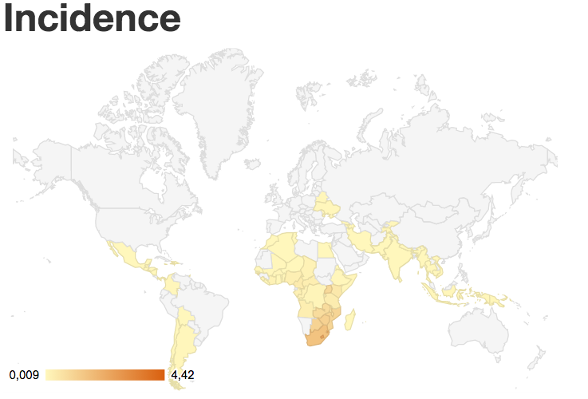

Figure1

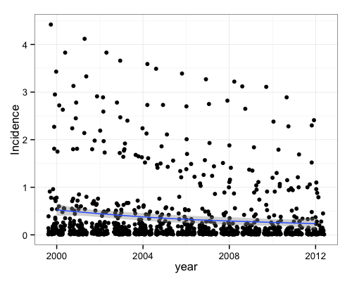

Figure2

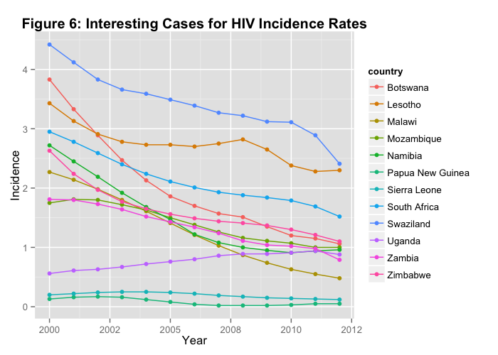

Figure6

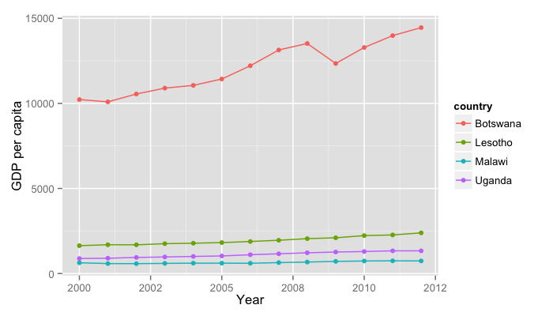

Figure9

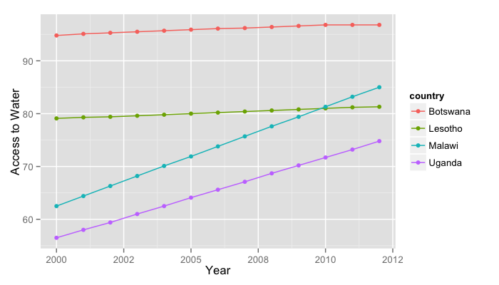

Figure7

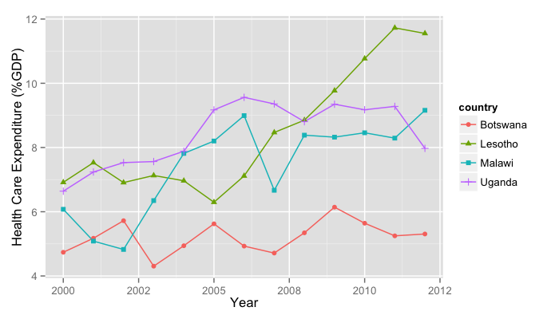

Figure12

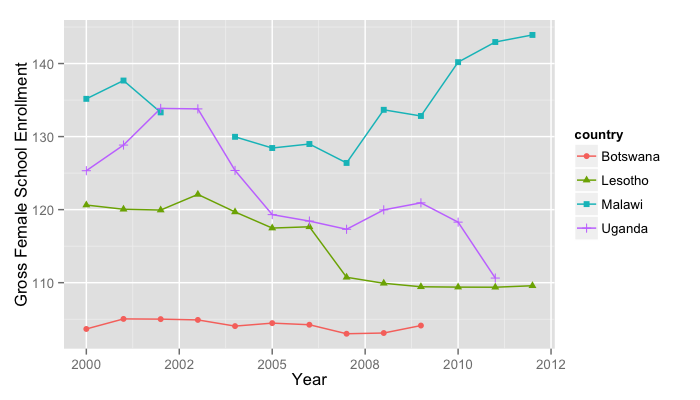

Figure10

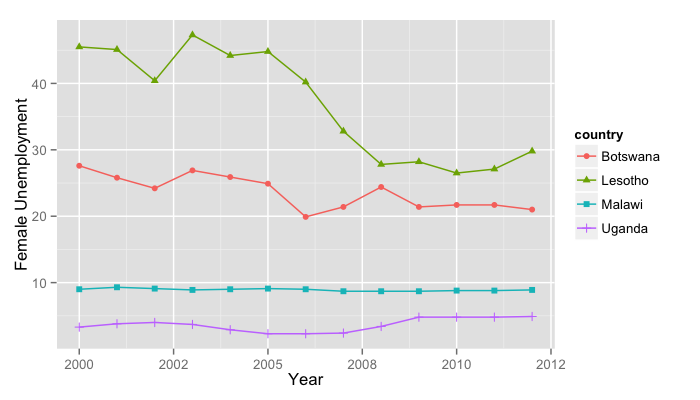

Figure11

## The Model

To answer our research question we will estimate the following equation:

\[ I_{it} = {\beta}_0 +{\beta}_1 SE_{it} + {\beta}_2 WLC_{it} + {\beta}_3 SCN_{it} + {\beta}_4 ILF_{it} + {\epsilon}_{it}\]

Where I stands for HIV/AIDS incidence, SE stands for socioeconomic factors, WLC stands for working and living conditions, SCN stands for social and community networks and ILF stands for individual lifestyle factors.

## Imputed missing values

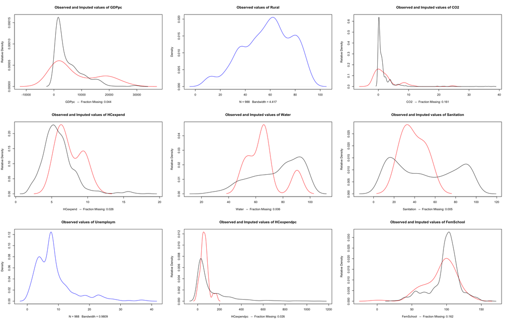

## Logistic Regression Results - Model 1

|  | Value | Std. Error | t-stat | p-value |
| --- | --- | --- | --- | --- |
| (Intercept) | -35.6218324 | 6.7466049 | -5.2799642 | 0.0000001 |
| lGDPpc | 0.2951011 | 0.3450118 | 0.8553363 | 0.3933605 |
| lRural | -2.6196651 | 0.5480205 | -4.7802318 | 0.0000020 |
| lCO2 | -0.5022846 | 0.1984871 | -2.5305652 | 0.0119562 |
| lHCexpend | 0.8584512 | 0.3776986 | 2.2728473 | 0.0231661 |
| lWater | -2.4259356 | 0.8578412 | -2.8279540 | 0.0048476 |
| lSanitation | 0.8837260 | 0.2792021 | 3.1651836 | 0.0015643 |
| lLifeExpect | 18.8580432 | 1.7344728 | 10.8724927 | 0.0000000 |
| lDPT | -0.4493320 | 0.9936581 | -0.4521998 | 0.6511306 |
| lMeasles | 1.4514934 | 1.1334166 | 1.2806354 | 0.2004039 |
| Inverse | 1.8312750 | 0.2617860 | 6.9953118 | 0.0000000 |
| lFemSchool | -5.7219481 | 0.7154938 | -7.9972011 | 0.0000000 |

## Predicted Probabilities - Female School Enrollment (in Quartiles)

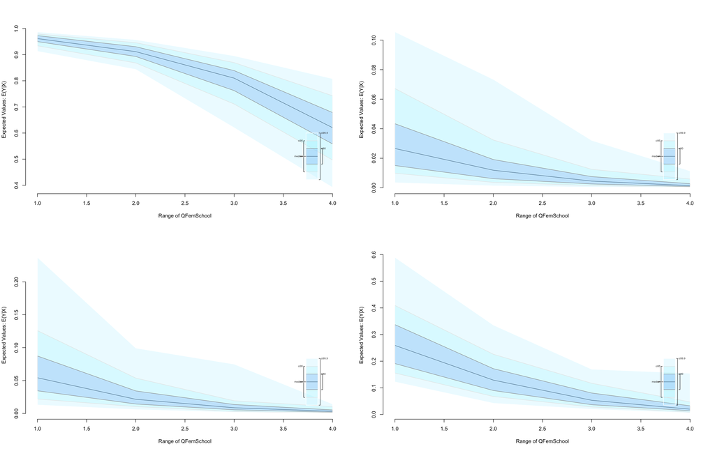

## Predicted Probabilities - Female Unemployment (in Quartiles)

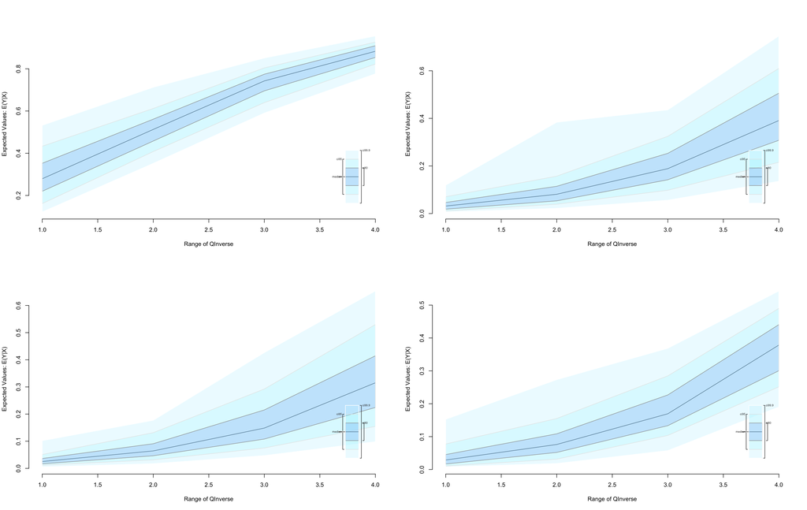

## Simple Linear Regression Results - Model 2

|  | Value | Std. Error | t-stat | p-value |
| --- | --- | --- | --- | --- |
| (Intercept) | 7.2456015 | 1.5921996 | 4.5506866 | 0.0000058 |
| lGDPpc | 0.0013852 | 0.0718802 | 0.0192712 | 0.9846254 |
| lRural | 0.2206246 | 0.1383246 | 1.5949775 | 0.1109971 |
| lCO2 | 0.1071585 | 0.0317924 | 3.3705695 | 0.0008184 |
| lHCexpend | 0.3920988 | 0.1135191 | 3.4540341 | 0.0007525 |
| lWater | -0.3349335 | 0.1844358 | -1.8159899 | 0.0700555 |
| lSanitation | 0.0732609 | 0.0709765 | 1.0321856 | 0.3021784 |
| lLifeExpect | -3.4074688 | 0.3281562 | -10.3836798 | 0.0000000 |
| lDPT | 0.6103465 | 0.2494635 | 2.4466365 | 0.0145189 |
| lMeasles | -0.0911128 | 0.2472198 | -0.3685496 | 0.7125164 |
| Inverse | -0.4246912 | 0.0481926 | -8.8123696 | 0.0000000 |
| lFemSchool | 0.5647599 | 0.1441131 | 3.9188656 | 0.0001213 |

## Fixed Effects Regression Results - Model 2

|  | Value | Std. Error | t-stat | p-value |
| --- | --- | --- | --- | --- |
| (Intercept) | -0.6879421 | 3.6343997 | -0.1892863 | 0.8498940 |
| lGDPpc | 0.0495495 | 0.1374625 | 0.3604582 | 0.7185086 |
| lRural | 2.9977783 | 0.6077547 | 4.9325467 | 0.0000010 |
| lCO2 | 0.0535780 | 0.0479406 | 1.1175923 | 0.2856483 |
| lHCexpend | -0.0104264 | 0.0959215 | -0.1086975 | 0.9134469 |
| lWater | -1.3537804 | 0.3572257 | -3.7897062 | 0.0001523 |
| lSanitation | -0.5051012 | 0.3244308 | -1.5568843 | 0.1195905 |
| lLifeExpect | -0.7811767 | 0.3264804 | -2.3927213 | 0.0167478 |
| lDPT | 0.7939004 | 0.1994350 | 3.9807487 | 0.0000689 |
| lMeasles | -0.7014315 | 0.1941604 | -3.6126387 | 0.0003036 |
| Inverse | -0.1160438 | 0.1026534 | -1.1304426 | 0.2584942 |
| lFemSchool | -0.0330022 | 0.1298444 | -0.2541676 | 0.7997437 |
| as.factor(country)Burundi | -3.8116925 | 0.5258212 | -7.2490282 | 0.0000000 |
| as.factor(country)Cameroon | -1.8256901 | 0.2668686 | -6.8411565 | 0.0000000 |
| as.factor(country)Central African Republic | -2.7898531 | 0.4274632 | -6.5265343 | 0.0000000 |
| as.factor(country)Chad | -4.3676551 | 0.5300927 | -8.2394167 | 0.0000000 |
| as.factor(country)Congo, Rep. | -1.9149976 | 0.5730841 | -3.3415647 | 0.0008941 |
| as.factor(country)Cote d'Ivoire | -2.2705724 | 0.4138072 | -5.4870303 | 0.0000000 |
| as.factor(country)Ethiopia | -5.5054999 | 0.5663290 | -9.7213806 | 0.0000000 |
| as.factor(country)Gabon | 1.7867424 | 0.6703152 | 2.6655258 | 0.0080711 |
| as.factor(country)Guinea-Bissau | -2.9094444 | 0.4254081 | -6.8391846 | 0.0000000 |
| as.factor(country)Kenya | -3.4391936 | 0.3323578 | -10.3478655 | 0.0000000 |
| as.factor(country)Lesotho | -1.6643084 | 0.3472133 | -4.7933320 | 0.0000028 |
| as.factor(country)Liberia | -2.7371949 | 0.5703932 | -4.7987861 | 0.0000017 |
| as.factor(country)Malawi | -3.1482613 | 0.5555605 | -5.6668200 | 0.0000000 |
| as.factor(country)Mozambique | -2.7579915 | 0.4177093 | -6.6026572 | 0.0000000 |
| as.factor(country)Namibia | -1.6151775 | 0.2329197 | -6.9344831 | 0.0000000 |
| as.factor(country)Nigeria | -2.9536672 | 0.2738752 | -10.7847200 | 0.0000000 |
| as.factor(country)South Africa | 0.5322046 | 0.1515299 | 3.5122085 | 0.0004503 |
| as.factor(country)Swaziland | -1.5423862 | 0.3296661 | -4.6786312 | 0.0000029 |
| as.factor(country)Tanzania | -3.8125983 | 0.5208258 | -7.3202941 | 0.0000000 |
| as.factor(country)Togo | -3.6450250 | 0.4705907 | -7.7456382 | 0.0000000 |
| as.factor(country)Uganda | -2.9806089 | 0.4485523 | -6.6449535 | 0.0000000 |
| as.factor(country)Zambia | -1.8542039 | 0.2583072 | -7.1782897 | 0.0000000 |
| as.factor(country)Zimbabwe | -1.3698990 | 0.3409878 | -4.0174429 | 0.0000592 |

## Conclusions and Limitations - Model 2

1. ** Linear Regression of Model 2 (countries with incidence above mean) **
- Significance of some variables changes
- Female School Enrollment and Female Unemployment remain highly significant
- Effect of Female Schooling becomes positive (!)
1. ** Fixed Effects Regression of Model 2 (countries with incidence above mean) **
- Significance of some variables changes compared to simple linear model
- Female School Enrollment and Female Unemployment become insignificant
- Immunisation rates for DPT & Measles become highly significant (!)